# Survey Results Task 3.3 731951

# B9 Provider of attended training sessions

Who provided the training sessions you attended? (choose all that apply)

| Variable | No | Yes |
| --- | --- | --- |
| An external organisation | 135 (80.8%) | 32 (19.2%) |
| Library | 139 (83.2%) | 28 (16.8%) |
| My institution | 74 (44.3%) | 93 (55.7%) |
| My professional association | 144 (86.2%) | 23 (13.8%) |
| My supervisor | 162 (97.0%) | 5 (3.0%) |
| Research school | 156 (93.4%) | 11 (6.6%) |
| Session at a conference | 137 (82.0%) | 30 (18.0%) |

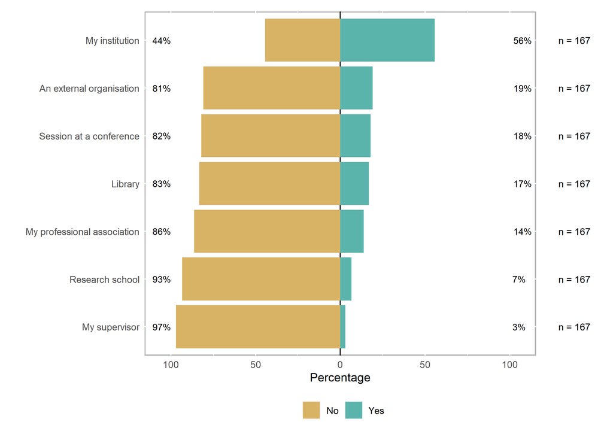

```r
answer_levels_3 <- c("No", "Yes")

b9_df <- df %>%
  select(starts_with("B9["))

b9_df_rec <- b9_df %>%
  mutate(across(.fns = factor, levels = answer_levels_3))

b9_df_rec %>%
  plot_likert(legend_rows = 1)
```

# B10 Preferred way to learn OS topics

What is your preferred way to learn open science topics? (choose all that apply)

| Variable | No | Yes |
| --- | --- | --- |
| Discussions with peers | 87 (52.1%) | 80 (47.9%) |
| I haven’t learnt about Open Science topics | 139 (83.2%) | 28 (16.8%) |
| Mandatory training | 145 (86.8%) | 22 (13.2%) |
| Optional training | 83 (49.7%) | 84 (50.3%) |
| Personal reading | 105 (62.9%) | 62 (37.1%) |

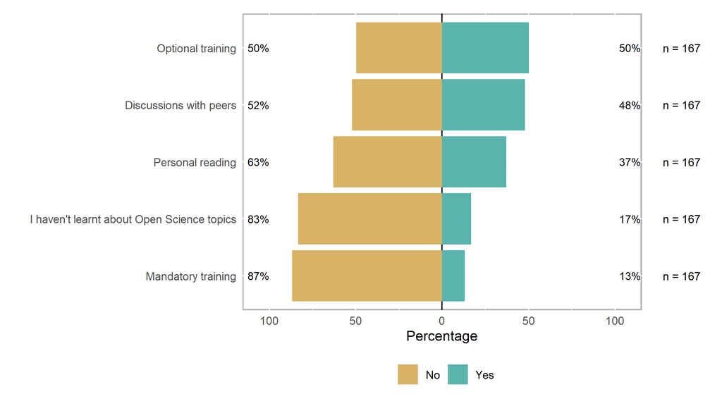

```r
b10_df <- df %>%
  select(starts_with("B10["))

b10_df_rec <- b10_df %>%
  mutate(across(.fns = factor, levels = answer_levels_3))

b10_df_rec %>%
  plot_likert(legend_rows = 1)
```

# B11 Has your awareness of open science practices increased after the training you attended?

Has your awareness of open science practices increased after the training you attended?

```r
answer_levels_4 <- c("Highly disagree", "Disagree",
                     "Neither agree nor disagree",
                     "Agree", "Highly agree")


b11_df <- df %>%
  select(starts_with("B11["))

b11_df_rec <- b11_df %>%
  mutate(across(.fns = factor, levels = answer_levels_4))

recode_successful(b11_df, b11_df_rec)
```

[1] “Component "B11[SQ001]": Mean absolute difference: 52” [2] “Component "B11[SQ002]": Mean absolute difference: 46” [3] “Component "B11[SQ003]": Mean absolute difference: 45” [4] “Component "B11[SQ004]": Mean absolute difference: 45”

| Variable | Highly disagree | Disagree | Neither agree nor disagree | Agree | Highly agree |
| --- | --- | --- | --- | --- | --- |
| I am aware of the benefits, but I don’t really practice open science | 14 (11.5%) | 36 (29.5%) | 36 (29.5%) | 33 (27.0%) | 3 (2.5%) |
| I am more aware of the opportunities offered by practicing open science | 5 (4.3%) | 7 (6.1%) | 30 (26.1%) | 61 (53.0%) | 12 (10.4%) |
| I incorporated some open science practices in my daily research work | 4 (3.3%) | 8 (6.6%) | 32 (26.4%) | 63 (52.1%) | 14 (11.6%) |
| I still don’t understand why I should make an extra effort | 32 (26.2%) | 48 (39.3%) | 29 (23.8%) | 10 (8.2%) | 3 (2.5%) |

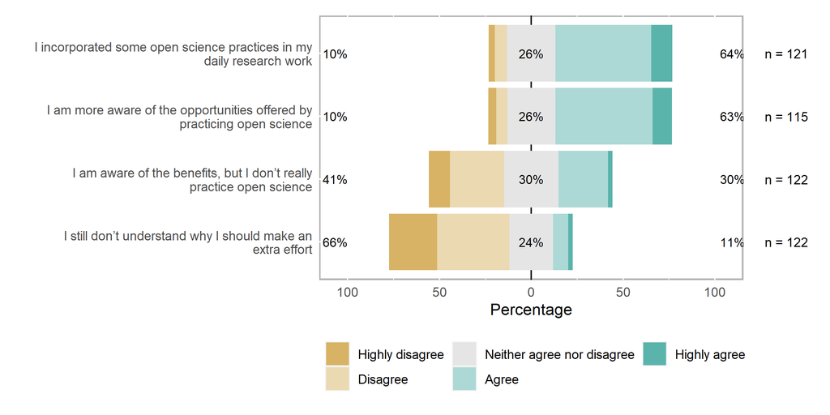

```r
b11_df_rec %>%
  plot_likert()
```

# B12 Share experience OS practices/tool with colleagues

Would you share your experience with open science practices and tools with colleagues?

| Variable | Highly disagree | Disagree | Neither agree nor disagree | Agree | Highly agree |
| --- | --- | --- | --- | --- | --- |
| I would recommend my colleagues some of the practices I am using | 2 (1.5%) | 7 (5.1%) | 30 (22.1%) | 73 (53.7%) | 24 (17.6%) |
| My colleagues wouldn’t make the effort | 10 (8.1%) | 54 (43.9%) | 38 (30.9%) | 15 (12.2%) | 6 (4.9%) |
| My research community already has established open science practices | 9 (7.0%) | 24 (18.6%) | 35 (27.1%) | 50 (38.8%) | 11 (8.5%) |
| My research community already has established tools and practices that don’t foresee open science | 12 (10.0%) | 34 (28.3%) | 43 (35.8%) | 29 (24.2%) | 2 (1.7%) |

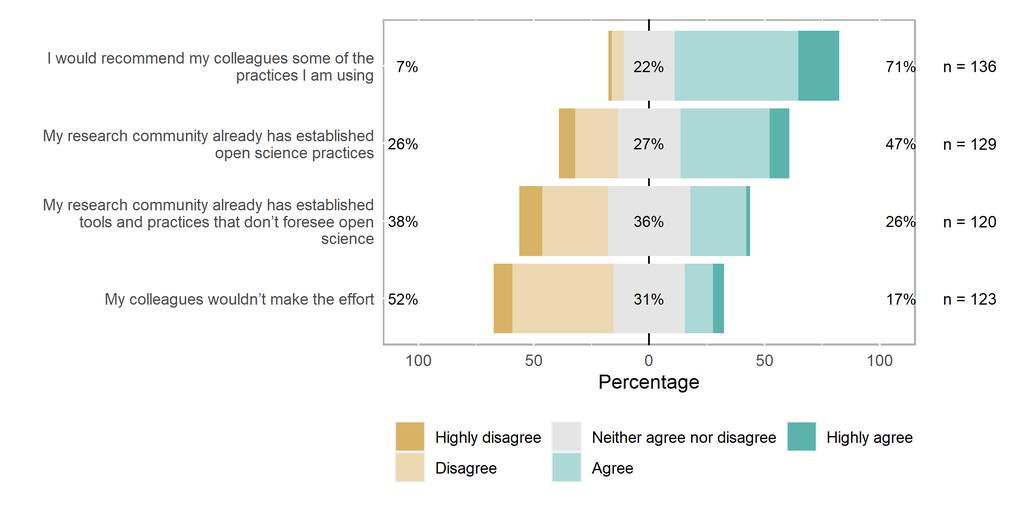

```r
b12_df <- df %>%
  select(starts_with("B12["))

b12_df_rec <- b12_df %>%
  mutate(across(.fns = factor, levels = answer_levels_4))

b12_df_rec %>%
  plot_likert()
```

# Further todos

- check out cases with weird first year of publication `df %>% filter(id %in% c(356, 420, 129))`